# GFDL-CM4_ssp245 annual, local tos to global tas pattern scaling

ACS

12/19/2019

# 1 Setup

## 1.1 Select model + helpful strings and other files

```r
esmname <- 'GFDL-CM4_ssp245'
esmfilelist <- list.files(paste0('cmip6_netcdf/', esmname), full.names = TRUE)
latvar <- 'lat'
lonvar <- 'lon'

# CMIP6 offers gr (regridded) and gn (native) resolutions; cannot get gn to open
# in some cases, there are gr1, gr2, etc. Unclear the details/differences.
# probably regridded to different scale. Fine as long as consistent within
# a given variable (tos vs tas)
gridchoice <- 'gr'

#yearrange <- '200601-210012'
siglvl <- 0.05        # significance level for statistical tests

coralsites <- as_tibble(read.csv('../data/cell_site_lat_longs.csv'))

hawaii <- paste0(rep('hi', 15), 1:15)
florida <- paste0(rep('fl', 9), 1:9)
pr <- paste0(rep('pr_usvi', 8), 1:8)
```

## 1.2 Helper functions

```r
# read in tas netcdfs via fldgen function
readtas <- function(fn) {read.general(fn, varname = 'tas',
                                     latvar=latvar, lonvar=lonvar)}

# read in tos netcdfs via fldgen function
readtos <- function(fn) {read.general(fn, varname = 'tos',
                                     latvar=latvar, lonvar=lonvar)}

# convert a matrix of nMonthYearRealizations X ngrid data to a list of 12
# matrices that are nYearRealizations X ngrid.
monthparser <- function(dat){

  # number of years X realizations
  # ie the number of rows that will go in each month's matrix
  numYxR <- 1:(nrow(dat)/12)

  # make a list with 12 entires - each entrie has the
  monthvardata <- lapply(as.list(1:12), function(g){

    rownums <- g + 12*(numYxR-1)
    return(dat[rownums, ])
  } )

  return(monthvardata)
}
```

# 2 loading and shaping data

The CMIP6 projection runs are now 2015-2100. Currently, we are just using that range for `tas` and `tos` values to build the pattern. However, we do have to bring in a 2007 set of `tos` values because COMBO requires ocean temperature values to be in terms of change from 2007.

The netcdfs are too large to track on GitHub and are all located on pic. This R markdown includes the list of files used to create this pattern so that a user can download the needed files and re-produce the pattern and analysis. Similarly, this markdown can be adapted for creating a pattern and analysis for a different ESM, using the printed lists of files to identify the analogous files for a different ESM.

## 2.1 Annual ESM global average tas

```r
# vector with relevant tas files
taslist <- esmfilelist[grepl('tas', esmfilelist)]
esmind1 <- grepl(esmname, taslist)
taslist <- taslist[esmind1]
print(taslist)
```

```
## [1] "cmip6_netcdf/GFDL-CM4_ssp245/tas_Amon_GFDL-CM4_ssp245_r1i1p1f1_gr1_201501-210012.nc"
```

```r
#read in and concatenate the tas netcdfs
tasgrid <- concatGrids.general(lapply(taslist, readtas))
print(paste('Latitude is divided over', length(tasgrid$lat), 'bins =', 180/length(tasgrid$lat), 'degrees'))
```

```
## [1] "Latitude is divided over 180 bins = 1 degrees"
```

```r
print(paste('Longitude is divided over', length(tasgrid$lon), 'bins =', 360/length(tasgrid$lon), 'degrees'))
```

```
## [1] "Longitude is divided over 288 bins = 1.25 degrees"
```

```r
str(tasgrid)
```

```
## List of 6
##  $ vardata : num [1:1032, 1:51840] 241 231 220 215 216 ...
##  $ globalop: num [1:51840, 1] 2.64e-07 7.93e-07 1.32e-06 1.85e-06 2.38e-06 ...
##  $ lat     : num [1:180(1d)] -89.5 -88.5 -87.5 -86.5 -85.5 -84.5 -83.5 -82.5 -81.5 -80.5 ...
##  $ lon     : num [1:288(1d)] 0.625 1.875 3.125 4.375 5.625 ...
##  $ time    : num [1:1032] 0 1 2 3 4 5 6 7 8 9 ...
##  $ tags    :List of 1
##   ..$ tas_Amon_GFDL-CM4_ssp245_r1i1p1f1_gr1_201501-210012.nc: num [1:2] 1 1032
##  - attr(*, "class")= chr "griddata"
```

```r
# Convert temperature data from K to C
tasgrid$vardata <- (tasgrid$vardata - 273.15)


# monthly tgav values
# parse out the data from one matrix with all months, years, realizations to
# a list of 12 matrices with all years realizations.
monthlyvardata <- monthparser(tasgrid$vardata)

# calculate the global average value of tas for each month
tgav_monthly <- lapply(monthlyvardata, function(g){

  g %*% tasgrid$globalop

})

str(tgav_monthly)
```

```
## List of 12
##  $ : num [1:86, 1] 11.9 12.1 11.6 11.8 11.8 ...
##  $ : num [1:86, 1] 12.2 12.3 11.8 12 12.1 ...
##  $ : num [1:86, 1] 12.7 13 12.6 12.7 12.7 ...
##  $ : num [1:86, 1] 13.7 13.9 13.6 13.8 13.7 ...
##  $ : num [1:86, 1] 14.8 14.7 14.7 14.8 14.8 ...
##  $ : num [1:86, 1] 15.4 15.4 15.4 15.5 15.4 ...
##  $ : num [1:86, 1] 15.7 15.7 15.6 15.9 15.7 ...
##  $ : num [1:86, 1] 15.5 15.6 15.6 15.5 15.5 ...
##  $ : num [1:86, 1] 14.9 14.8 14.9 15 14.9 ...
##  $ : num [1:86, 1] 14 13.7 13.9 14 14 ...
##  $ : num [1:86, 1] 12.8 12.6 12.8 12.8 12.9 ...
##  $ : num [1:86, 1] 12.2 11.8 12 12 12 ...
```

```r
saveRDS(tgav_monthly, paste0('tgavs/monthly_tgav_', esmname, '.rds'))


# to get annual tgav, first get _annual_ avg tas in each cell
# ie go from monthly to yearly
tas_annual_gridded <- apply(tasgrid$vardata, 2, function(vec){

  numYxR <- length(vec)/12

  yearmean <- sapply(1:numYxR, function(i){

    janrownum <- 1 + 12*(i-1)

    return(mean(vec[janrownum:(janrownum + 11)]))

  } )
})


# then gridded to global
tgav <- tas_annual_gridded %*% tasgrid$globalop
str(tgav)
```

```
##  num [1:86, 1] 13.8 13.8 13.7 13.8 13.8 ...
```

```r
saveRDS(tgav, paste0('tgavs/tgav_', esmname, '.rds'))
```

## 2.2 Annual ESM gridcell tos

`delta_annual_tos` in year `t` is `annual_tos(t) - annual_tos(2007)`.

```r
# vector with relevant tos files
toslist <- esmfilelist[grepl('tos', esmfilelist)]
esmind1 <- grepl(gridchoice, toslist)
toslist <- toslist[esmind1]
esmind2 <- grepl('ssp245_',toslist)
toslist <- toslist[esmind2]
print(toslist)
```

```
## [1] "cmip6_netcdf/GFDL-CM4_ssp245/tos_Omon_GFDL-CM4_ssp245_r1i1p1f1_gr_201501-203412.nc"
## [2] "cmip6_netcdf/GFDL-CM4_ssp245/tos_Omon_GFDL-CM4_ssp245_r1i1p1f1_gr_203501-205412.nc"
## [3] "cmip6_netcdf/GFDL-CM4_ssp245/tos_Omon_GFDL-CM4_ssp245_r1i1p1f1_gr_205501-207412.nc"
## [4] "cmip6_netcdf/GFDL-CM4_ssp245/tos_Omon_GFDL-CM4_ssp245_r1i1p1f1_gr_207501-209412.nc"
## [5] "cmip6_netcdf/GFDL-CM4_ssp245/tos_Omon_GFDL-CM4_ssp245_r1i1p1f1_gr_209501-210012.nc"
```

```r
#read in and concatenate the tas netcdfs
tosgrid <- concatGrids.general(lapply(toslist, readtos))
print(paste('Latitude is divided over', length(tosgrid$lat), 'bins =', 180/length(tosgrid$lat), 'degrees'))
```

```
## [1] "Latitude is divided over 180 bins = 1 degrees"
```

```r
print(paste('Longitude is divided over', length(tosgrid$lon), 'bins =', 360/length(tosgrid$lon), 'degrees'))
```

```
## [1] "Longitude is divided over 360 bins = 1 degrees"
```

```r
str(tosgrid)
```

```
## List of 6
##  $ vardata : num [1:1032, 1:64800] NA NA NA NA NA NA NA NA NA NA ...
##  $ globalop: num [1:64800, 1] 2.12e-07 6.35e-07 1.06e-06 1.48e-06 1.90e-06 ...
##  $ lat     : num [1:180(1d)] -89.5 -88.5 -87.5 -86.5 -85.5 -84.5 -83.5 -82.5 -81.5 -80.5 ...
##  $ lon     : num [1:360(1d)] 0.5 1.5 2.5 3.5 4.5 5.5 6.5 7.5 8.5 9.5 ...
##  $ time    : num [1:1032] 0 1 2 3 4 5 6 7 8 9 ...
##  $ tags    :List of 5
##   ..$ tos_Omon_GFDL-CM4_ssp245_r1i1p1f1_gr_201501-203412.nc: num [1:2] 1 240
##   ..$ tos_Omon_GFDL-CM4_ssp245_r1i1p1f1_gr_203501-205412.nc: num [1:2] 241 480
##   ..$ tos_Omon_GFDL-CM4_ssp245_r1i1p1f1_gr_205501-207412.nc: num [1:2] 481 720
##   ..$ tos_Omon_GFDL-CM4_ssp245_r1i1p1f1_gr_207501-209412.nc: num [1:2] 721 960
##   ..$ tos_Omon_GFDL-CM4_ssp245_r1i1p1f1_gr_209501-210012.nc: num [1:2] 961 1032
##  - attr(*, "class")= chr "griddata"
```

```r
# Convert temperature data from K to C
tosgrid$vardata <- (tosgrid$vardata - 273.15)

# annual values from the monthly
tos_annual_gridded <- apply(tosgrid$vardata, 2, function(vec){

  numYxR <- length(vec)/12

  yearmean <- sapply(1:numYxR, function(i){

    janrownum <- 1 + 12*(i-1)

    return(mean(vec[janrownum:(janrownum + 11)]))

  } )
})


# for COMBO, tos values actually have to be in change from 2007 tos.
## TO DO make the file choice + row corresponding to 2007 more
## endogenous based on the file names. Hardcoded right now for
## expediency
# get the 2007 historical file:
tos2007filename <-esmfilelist[grepl('tos', esmfilelist)]
esmind1 <- grepl(gridchoice, tos2007filename )
tos2007filename <- tos2007filename[esmind1]
esmind2 <- grepl('historical_', tos2007filename)
tos2007filename <- tos2007filename[esmind2][1]
print(tos2007filename)
```

```
## [1] "cmip6_netcdf/GFDL-CM4_ssp245/tos_Omon_GFDL-CM4_historical_r1i1p1f1_gr_199001-200912.nc"
```

```r
tos2007grid <- concatGrids.general(lapply(tos2007filename, readtos))

tos2007_annual_grid <- apply(tos2007grid$vardata, 2, function(vec){

  numYxR <- length(vec)/12

  yearmean <- sapply(1:numYxR, function(i){

    janrownum <- 1 + 12*(i-1)

    return(mean(vec[janrownum:(janrownum + 11)]))

  } )
})

# 2007 is the 18th row because the historical file runs 1990-2009.
tos2007_annual_grid <- tos2007_annual_grid[18,]

# Calculate the deltaTOS values over the projection period,
# where the delta is from TOS2007, per COMBO having that base year.
delta_tos_annual_gridded <- t(apply(tos_annual_gridded, 1, function(row){ row - tos2007_annual_grid }))
```

# 3 na values for tos

`tos` is only defined over the ocean. All columns corresponding to land cells are populated with NA values.

These were not dropped when we used `tas` to calculate global average temperatures in each month. I’m inclined to keep it that way because:

1. It’s a truer representation of tgav.
2. It would be annoying to rewrite the code above to drop land cells from the `tas` data for calculating tgav. Doable, but annoying.

If we think the inconsistency would be an issue, I’ll do it with no further complaints.

```r
# fldgen drop_na only works on full fldgen objects
delta_tosgrid_ann <- tosgrid
delta_tosgrid_ann$vardata <- delta_tos_annual_gridded
delta_tosgrid_ann$time <- (0:(nrow(delta_tos_annual_gridded) -1) )

# For each month, drop the NA values
annual_ocean_data <- drop_NAs(delta_tosgrid_ann)
```

# 4 Pattern scaling

## 4.1 check appropriateness of scaling at the sites of interest

Limited number of sites = can check if the annual local TOS is actually related to Tgav

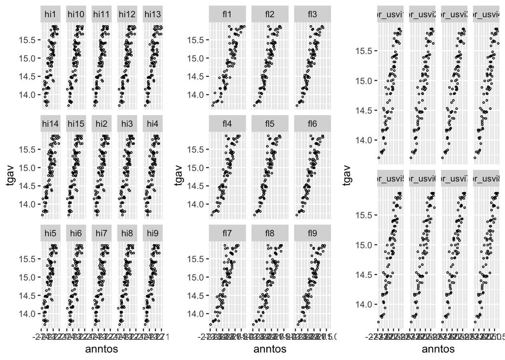

## 4.2 Do the scaling

```r
# use the fldgen pattern scaling convenience function and carefully
# pair the correct month specific gridded `tos` data with the
# correct month specifc `tgav` data to result in a list of
# patterns, one for each month.
annual_pattern <- pscl_analyze(annual_ocean_data$vardata, tgav)
```

## 4.3 save the pattern

```r
# the pattern is only for the ocean grid cells
# to make the .OUT files for combo, the full
# grid is necessary.
# It's also convenient  to have the grid
# lon and lat values over the ocean and their
# corresponding colnumber in the `tos` data
# that has no NAs.
# So output these in a list with the pattern.


saveRDS(list(annual_pattern = annual_pattern,
             lonlat = lonlat,
             fulllon = annual_ocean_data$lon,
             fulllat = annual_ocean_data$lat),
        paste0('patterns/', esmname, '_annualtos.rds'))
```

# 5 Analysis

## 5.1 Check residuals

### 5.1.1 Zero mean

Residuals in each grid cell for each month should be centered around 0 over time if pattern scaling was successful. We will calculate this mean over time in each grid cell for each month and print the summary of all the grid cell time means for each month to make sure they are all centered at 0. Note that this measure *does* allow for cancellation of errors - we are just checking where the mean of the distribution of residuals actually lies, not measuring errors:

```r
mt <- apply(annual_pattern$r, 2, mean)
print(as.vector(summary(mt)))
```

```
## [1] -1.807012e-16 -7.033289e-18 -5.507684e-20 -3.216152e-20  6.866620e-18
## [6]  1.948775e-16
```

## 5.2 RMS

RMS is a measure that accumulates errors - in a particular grid cell, for a given month, how many degrees off is the linear model SST value from the true value in each year on average.

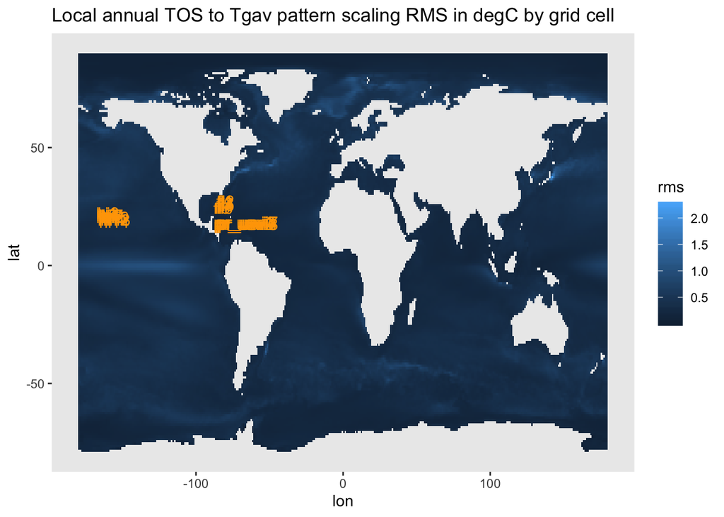

```
## [1] "Global area weighted average rmse = 0.351899970552505 degC"
```

We examine pattern scaling rms in more detail at each site of interest

```r
# Get the annual TOS in each grid cell as predicted
# by the annual pattern for the tgav
reconstr_annual_tos <- pscl_apply(annual_pattern, tgav)


# pull out just the coral sites for the reconstructed pattern
tmp <- as_tibble(reconstr_annual_tos[, coralIDS$colnumber])
colnames(tmp) <- coralIDS$cell_id

tmp %>%
  bind_cols(tibble(tgav = tgav)) %>%
  gather(cell_id, reconst_anntos, -tgav)  %>%
  left_join(coral_tos_ann, by = c('tgav', 'cell_id')) %>%
  mutate(resids = anntos - reconst_anntos) %>%
  group_by(cell_id) %>%
  summarise(rms = sqrt(mean((resids*resids)))) %>%
  ungroup %>%
  left_join(coralsites, by = 'cell_id')->
  coral_tos_ann_reconstr
```

```r
rm(tmp)


  p2 <-  ggplot(filter(coral_tos_ann_reconstr, cell_id %in% hawaii), aes(x = long, y = lat, fill = rms)) +
    geom_tile()  +
    annotate("text", x = coralsites[1,]$long, y = coralsites[1,]$lat, label = coralsites[1,]$cell_id,
             color = 'orange') +
    annotate("text", x = coralsites[2,]$long, y = coralsites[2,]$lat, label = coralsites[2,]$cell_id,
             color = 'orange') +
    annotate("text", x = coralsites[3,]$long, y = coralsites[3,]$lat, label = coralsites[3,]$cell_id,
             color = 'orange') +
    annotate("text", x = coralsites[4,]$long, y = coralsites[4,]$lat, label = coralsites[4,]$cell_id,
             color = 'orange') +
    annotate("text", x = coralsites[5,]$long, y = coralsites[5,]$lat, label = coralsites[5,]$cell_id,
             color = 'orange') +
    annotate("text", x = coralsites[6,]$long, y = coralsites[6,]$lat, label = coralsites[6,]$cell_id,
             color = 'orange') +
    annotate("text", x = coralsites[7,]$long, y = coralsites[7,]$lat, label = coralsites[7,]$cell_id,
             color = 'orange') +
    annotate("text", x = coralsites[8,]$long, y = coralsites[8,]$lat, label = coralsites[8,]$cell_id,
             color = 'orange') +
    annotate("text", x = coralsites[9,]$long, y = coralsites[9,]$lat, label = coralsites[9,]$cell_id,
             color = 'orange') +
    annotate("text", x = coralsites[10,]$long, y = coralsites[10,]$lat, label = coralsites[10,]$cell_id,
             color = 'orange') +
    annotate("text", x = coralsites[11,]$long, y = coralsites[11,]$lat, label = coralsites[11,]$cell_id,
             color = 'orange') +
    annotate("text", x = coralsites[12,]$long, y = coralsites[12,]$lat, label = coralsites[12,]$cell_id,
             color = 'orange') +
    annotate("text", x = coralsites[13,]$long, y = coralsites[13,]$lat, label = coralsites[13,]$cell_id,
             color = 'orange') +
    annotate("text", x = coralsites[14,]$long, y = coralsites[14,]$lat, label = coralsites[14,]$cell_id,
             color = 'orange') +
    annotate("text", x = coralsites[15,]$long, y = coralsites[15,]$lat, label = coralsites[15,]$cell_id,
             color = 'orange') +
    theme( panel.grid.major = element_blank(), panel.grid.minor = element_blank())


  p3 <-  ggplot(filter(coral_tos_ann_reconstr, cell_id %in% florida),
                       aes(x = long, y = lat, fill = rms)) +
    geom_tile() +
    annotate("text", x = coralsites[16,]$long, y = coralsites[16,]$lat, label = coralsites[16,]$cell_id,
             color = 'orange') +
    annotate("text", x = coralsites[17,]$long, y = coralsites[17,]$lat, label = coralsites[17,]$cell_id,
             color = 'orange') +
    annotate("text", x = coralsites[18,]$long, y = coralsites[18,]$lat, label = coralsites[18,]$cell_id,
             color = 'orange') +
    annotate("text", x = coralsites[19,]$long, y = coralsites[19,]$lat, label = coralsites[19,]$cell_id,
             color = 'orange') +
    annotate("text", x = coralsites[20,]$long, y = coralsites[20,]$lat, label = coralsites[20,]$cell_id,
             color = 'orange') +
    annotate("text", x = coralsites[21,]$long, y = coralsites[21,]$lat, label = coralsites[21,]$cell_id,
             color = 'orange') +
    annotate("text", x = coralsites[22,]$long, y = coralsites[22,]$lat, label = coralsites[22,]$cell_id,
             color = 'orange') +
    annotate("text", x = coralsites[23,]$long, y = coralsites[23,]$lat, label = coralsites[23,]$cell_id,
             color = 'orange') +
    annotate("text", x = coralsites[24,]$long, y = coralsites[24,]$lat, label = coralsites[24,]$cell_id,
             color = 'orange') +
    theme( panel.grid.major = element_blank(), panel.grid.minor = element_blank())


 p4 <-  ggplot(filter(coral_tos_ann_reconstr, cell_id %in% pr),
                       aes(x = long, y = lat, fill = rms)) +
    geom_tile() +
    annotate("text", x = coralsites[25,]$long, y = coralsites[25,]$lat, label = coralsites[25,]$cell_id,
             color = 'orange') +
    annotate("text", x = coralsites[26,]$long, y = coralsites[26,]$lat, label = coralsites[26,]$cell_id,
             color = 'orange') +
    annotate("text", x = coralsites[27,]$long, y = coralsites[27,]$lat, label = coralsites[27,]$cell_id,
             color = 'orange') +
    annotate("text", x = coralsites[28,]$long, y = coralsites[28,]$lat, label = coralsites[28,]$cell_id,
             color = 'orange') +
    annotate("text", x = coralsites[29,]$long, y = coralsites[29,]$lat, label = coralsites[29,]$cell_id,
             color = 'orange') +
    annotate("text", x = coralsites[30,]$long, y = coralsites[30,]$lat, label = coralsites[30,]$cell_id,
             color = 'orange') +
    annotate("text", x = coralsites[31,]$long, y = coralsites[31,]$lat, label = coralsites[31,]$cell_id,
             color = 'orange') +
    annotate("text", x = coralsites[32,]$long, y = coralsites[32,]$lat, label = coralsites[32,]$cell_id,
             color = 'orange') +
    theme( panel.grid.major = element_blank(), panel.grid.minor = element_blank())


 ggsave(paste0('figures/', esmname, '_rms_annpscl_HI.png'), p2,
         width = 14, height = 11, units = 'in')

 ggsave(paste0('figures/', esmname, '_rms_annpscl_FL.png'), p3,
         width = 14, height = 11, units = 'in')

 ggsave(paste0('figures/', esmname, '_rms_annpscl_PR.png'), p4,
         width = 14, height = 11, units = 'in')

write.csv(coral_tos_ann_reconstr, paste0('rms/', esmname, '_coralsite_rms_annpscl.csv'), row.names = F)
```